# Blake Conrad – HW7 – PCA & K-means

## Instructions

The data set music-all.csv Preview the documentView in a new window was constructed by taking the first 40 seconds of the wave file of each song and constructing features such as the average, variance, max of the frequency, and variables related to the loudness and location of peaks in the wave.

- Apply Principal Component Analysis (PCA) to the data set. Make a scatter plot of the first two components against each other and color the points by artist.
- Apply k-means clustering to the data set and create a similar scatter plot to 1) except with the colors determined by the k-means categories. Compare how well k-means performed.

## Include Libraries

```r
library(ggplot2)
```

## Import and Scale Data

```r
setwd("/Users/bmc/Desktop/CSCI-49000/week_6/HW7")
df <- read.csv("music-all.csv", header=TRUE)
df_good <- df[complete.cases(df),c(1:3,4:ncol(df))]
df_good[,4:ncol(df)] <- scale(df_good[,4:ncol(df_good)], center=TRUE, scale=TRUE)
head(df_good)
```

|  | X | artist | type | lvar | lave | lmax | lper1 | lper2 | lper3 | lper4 | lper5 | lper6 | lper7 | lper8 | lper9 | lper10 | lper11 | lper12 | lper13 | lper14 | lper15 | lfreq1 | lfreq2 | lfreq3 | lfreq4 | lfreq5 | lfreq6 | lfreq7 | lfreq8 | … |
| --- | --- | --- | --- | --- | --- | --- | --- | --- | --- | --- | --- | --- | --- | --- | --- | --- | --- | --- | --- | --- | --- | --- | --- | --- | --- | --- | --- | --- | --- | --- |
| 3 | Take a Chance | Abba | Rock | -0.3533770 | -1.883760 | 0.5271555 | -0.7466649 | -0.7910800 | -0.9069294 | -0.8389541 | -0.8054641 | -0.7996802 | -0.7582056 | -0.7165181 | -0.7104384 | -0.7016464 | -0.6700609 | -0.6434236 | -0.6229991 | -0.6253888 | -0.592179 | -0.6383661 | -0.2063637 | -0.6356614 | -0.7424578 | -0.8037389 | -0.04055946 | -0.4236743 | -0.9525232 | … |
| 4 | Mamma Mia | Abba | Rock | -0.4187303 | -1.731851 | 0.8232014 | -0.5953139 | -0.5864903 | -0.5929923 | -0.8389541 | -0.8054641 | -0.7996802 | -0.7582056 | -0.7165181 | -0.7104384 | -0.7016464 | -0.6700609 | -0.6434236 | -0.6229991 | -0.6253888 | -0.592179 | -1.0354454 | -1.0827807 | -1.0331033 | -1.1542964 | -1.0428849 | -0.94767101 | -1.1377921 | -1.1671156 | … |
| 6 | Super Trouper | Abba | Rock | -0.5453849 | -1.302654 | 0.4285907 | -0.7466649 | -0.7910800 | -0.9069294 | -0.8389541 | -0.8054641 | -0.7996802 | -0.7582056 | -0.7165181 | -0.7104384 | -0.7016464 | -0.6700609 | -0.6434236 | -0.6229991 | -0.6253888 | -0.592179 | -0.8538139 | -0.9043337 | -0.8491742 | -0.5309479 | -0.9058225 | -0.88120110 | -0.9772048 | -0.9699682 | … |
| 7 | I Have A Dream | Abba | Rock | -0.6021602 | -1.355919 | -0.8409142 | -0.7466649 | -0.7910800 | -0.9069294 | -0.8389541 | -0.8054641 | -0.7996802 | -0.7582056 | -0.7165181 | -0.7104384 | -0.7016464 | -0.6700609 | -0.6434236 | -0.6229991 | -0.6253888 | -0.592179 | 0.5498819 | 0.5792838 | 0.3027369 | 0.2904453 | -0.3583695 | 0.27156667 | -0.4829906 | 0.3200139 | … |
| 9 | Money | Abba | Rock | -0.4805121 | -1.447921 | 0.1275052 | -0.7466649 | -0.7910800 | -0.9069294 | -0.8389541 | -0.8054641 | -0.7996802 | -0.7582056 | -0.7165181 | -0.7104384 | -0.7016464 | -0.6700609 | -0.6434236 | -0.6229991 | -0.6253888 | -0.592179 | -0.1326191 | -0.2750099 | -0.3721368 | -0.4716240 | -0.1058113 | -0.76609453 | -0.5279999 | -0.4631834 | … |
| 10 | SOS | Abba | Rock | -0.5972014 | -1.404881 | -0.7450450 | -0.4439629 | -0.5864903 | -0.5929923 | -0.8389541 | -0.8054641 | -0.7996802 | -0.7582056 | -0.7165181 | -0.7104384 | -0.7016464 | -0.6700609 | -0.6434236 | -0.6229991 | -0.6253888 | -0.592179 | -0.5214934 | -0.4537246 | -0.5200718 | -0.6234682 | -0.5098859 | -0.56570180 | -0.6185641 | 0.3289926 | … |

```r
head(df)
```

|  | X | artist | type | lvar | lave | lmax | lper1 | lper2 | lper3 | lper4 | lper5 | lper6 | lper7 | lper8 | lper9 | lper10 | lper11 | lper12 | lper13 | lper14 | lper15 | lfreq1 | lfreq2 | lfreq3 | lfreq4 | lfreq5 | lfreq6 | lfreq7 | lfreq8 | … |
| --- | --- | --- | --- | --- | --- | --- | --- | --- | --- | --- | --- | --- | --- | --- | --- | --- | --- | --- | --- | --- | --- | --- | --- | --- | --- | --- | --- | --- | --- | --- |
| 1 | Dancing Queen | Abba | Rock | 17600800 | -90.007 | 29921 | 0.001 | 0.001 | 0.001 | 0.001 | 0.001 | 0.001 | 0.001 | 0.000 | 0.000 | 0.000 | 0.000 | 0.000 | 0.000 | 0.000 | 0.000 | 54.148 | 64.221 | 59.574 | 60.878 | 66.240 | 54.380 | 54.990 | 659.076 | … |
| 2 | Knowing Me | Abba | Rock | 9543020 | -75.767 | 27626 | 0.002 | 0.002 | 0.001 | 0.001 | 0.001 | 0.001 | 0.001 | 0.001 | 0.001 | 0.001 | 0.001 | 0.001 | 0.001 | 0.001 | 0.001 | 58.417 | 61.929 | 97.320 | 60.184 | 55.810 | 63.737 | 56.651 | 56.630 | … |
| 3 | Take a Chance | Abba | Rock | 9049480 | -98.063 | 26372 | 0.001 | 0.001 | 0.001 | 0.001 | 0.001 | 0.001 | 0.001 | 0.001 | 0.001 | 0.001 | 0.001 | 0.001 | 0.001 | 0.001 | 0.001 | 124.594 | 185.514 | 124.573 | 124.678 | 92.778 | 248.368 | 184.567 | 84.934 | … |
| 4 | Mamma Mia | Abba | Rock | 7557440 | -90.471 | 28898 | 0.002 | 0.002 | 0.002 | 0.001 | 0.001 | 0.001 | 0.001 | 0.001 | 0.001 | 0.001 | 0.001 | 0.001 | 0.001 | 0.001 | 0.001 | 49.291 | 48.050 | 48.870 | 48.765 | 48.933 | 73.032 | 47.104 | 49.753 | … |
| 5 | Lay All You | Abba | Rock | 6282290 | -88.953 | 27940 | 0.001 | 0.001 | 0.001 | 0.001 | 0.001 | 0.001 | NA | 0.001 | 0.001 | 0.001 | 0.001 | 0.001 | 0.001 | 0.001 | 0.001 | 88.341 | 72.149 | 70.677 | 73.999 | 81.759 | 79.551 | 68.469 | 68.763 | … |
| 6 | Super Trouper | Abba | Rock | 4665870 | -69.021 | 25531 | 0.001 | 0.001 | 0.001 | 0.001 | 0.001 | 0.001 | 0.001 | 0.001 | 0.001 | 0.001 | 0.001 | 0.001 | 0.001 | 0.001 | 0.001 | 83.736 | 76.039 | 83.904 | 163.665 | 74.062 | 85.880 | 78.016 | 82.074 | … |

## Apply and Plot PCA

Get the top two components and do a scatter plot of them colored (or grouped) by Artist

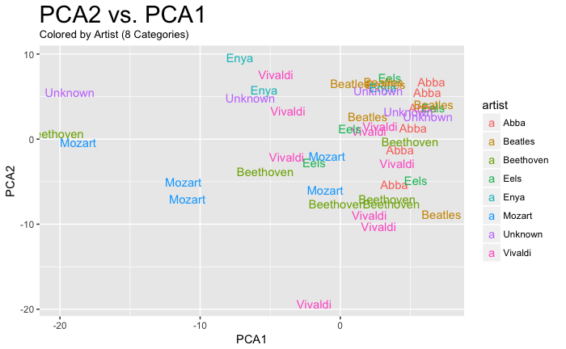

```r
pca <- prcomp(df_good[,4:ncol(df_good)])
df_good$PCA1 <- pca$x[,1]
df_good$PCA2 <- pca$x[,2]
plt <- ggplot(df_good, aes(PCA1,PCA2)) + geom_text(aes(label=artist, color=artist))
plt <- plt + ggtitle("PCA2 vs. PCA1", subtitle = "Colored by Artist (8 Categories)")
plt <- plt + theme(plot.title = element_text(size = rel(2.0)))
plt
```

## Apply and Plot K-means on PCA Features (The first two have the highest variance)

Pick the top two components and do a scatter plot of them colored (or grouped) by the Clusters in K-means *{k=length(unique(df_good$artist))}*

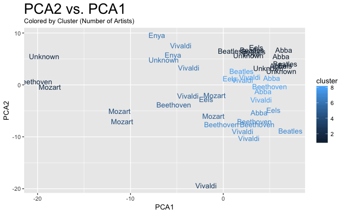

```r
cluster <- kmeans(df_good[,c("PCA1","PCA2")], centers=length(unique(df_good$artist)), nstart=30, iter.max=50)
df_good$cluster <- cluster$cluster
plt2 <- ggplot(df_good, aes(PCA1,PCA2)) + geom_text(aes(label=artist, color=cluster))
plt2 <- plt2 + ggtitle("PCA2 vs. PCA1", subtitle = "Colored by Cluster (Number of Artists)")
plt2 <- plt2 + theme(plot.title = element_text(size = rel(2.0)))
plt2
```